```r
knitr::opts_chunk$set(echo = TRUE)
library(readr)
library(dplyr)
library(tidyr)
```

```r
library(ggplot2)
library(scales)
library(tidytext)
library(textstem)
library(clinspacy)
library(topicmodels)
```

This practical is based on exploratory data analysis, named entity recognition, and topic modelling of unstructured medical note free-text data derived from electronic medical records (EMR). Real EMR data is very difficult to access without a specific need/request so this data set is derived from [medical transcription](https://mtsamples.com/) data instead. I’ll also caveat that the options of natural language processing (NLP) in R are far inferior to those available in Python.

First, install the packages in the setup block (`install.packages(c("readr", "dplyr", "tidyr", "ggplot2", "tidtext", "textstem", "clinspacy", "topicmodels"))`).

Note: To try and make it clearer which library certain functions are coming from clearer, I’ll try to do explicit imports throughout this notebook.

## Data Parsing

After that we can grab the dataset directly from the `clinspacy` library.

```r
raw.data <- clinspacy::dataset_mtsamples()
dplyr::glimpse(raw.data)
```

```
## Rows: 4,999
## Columns: 6
## $ note_id           <int> 1, 2, 3, 4, 5, 6, 7, 8, 9, 10, 11, 12, 13, 14, 15, 1~
## $ description       <chr> "A 23-year-old white female presents with complaint ~
## $ medical_specialty <chr> "Allergy / Immunology", "Bariatrics", "Bariatrics", ~
## $ sample_name       <chr> "Allergic Rhinitis", "Laparoscopic Gastric Bypass Co~
## $ transcription     <chr> "SUBJECTIVE:,  This 23-year-old white female present~
## $ keywords          <chr> "allergy / immunology, allergic rhinitis, allergies,~
```

There is no explanation or data dictionary with this dataset, which is a surprisingly common and frustrating turn of events!

**1** Using the output of dplyr’s `glimpse` command (or rstudio’s data viewer by clicking on `raw.data` in the Environment pane) provide a description of what you think each in this dataset contains.

**Q1 Answer: Note_id appears to be a unique identifier for each note. description appears to be topic of the note or reason for the medical visit. medical_specialty is exactly that (the medical specialty). Sample name looks like a combination of procedures and symptoms, transcription is a list of written notes including things like diagnoses, patient history, etc. And lastly, keywords are lists of keywords related to the patient record.**

Let’s see how many different medical specialties are featured in these notes:

```r
raw.data %>% dplyr::select(medical_specialty) %>% dplyr::n_distinct()
```

```
## [1] 40
```

So, how many transcripts are there from each specialty:

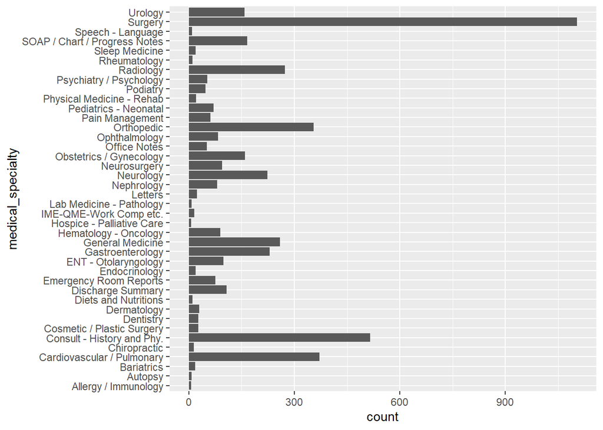

```r
ggplot2::ggplot(raw.data, ggplot2::aes(y=medical_specialty)) + ggplot2::geom_bar()
```

Let’s make our life easier and filter down to 3 specialties: a diagonstic/lab, a medical, and a surgical specialty

```r
analysis.data <- raw.data %>% dplyr::filter(medical_specialty %in% c("Neurology", "Radiology", "Neurosurgery"))
```

## Text Processing

Let’s now apply our standard pre-processing to the transcripts from these specialties.  
We are going to use the `tidytext` package to tokenise the transcript free-text.  
By default this tokenises to words but other options include characters, n-grams, sentences, lines, paragraphs, or separation around a regular expression.

```r
tokenized.data <- analysis.data %>% tidytext::unnest_tokens(word, transcription, to_lower=TRUE)
```

How many unique tokens are there in the transcripts from each specialty:

```r
tokenized.data %>% dplyr::group_by(medical_specialty) %>% dplyr::distinct(word) %>% dplyr::summarise(n=dplyr::n())
```

```
## # A tibble: 3 x 2
##   medical_specialty     n
##   <chr>             <int>
## 1 Neurology          9015
## 2 Neurosurgery       4263
## 3 Radiology          7313
```

However, there are a lot of extremely common words e.g., “the”, “of”, “to”, and so forth.  
These are known as stop words and we can remove them relative easily using a list from `tidytext::stop_words` and `dplyr::anti_join()`

**2** How many stop words are there in `tidytext::stop_words`?

**Q2 Answer:**

```r
?tidytext::stop_words
```

```
## starting httpd help server ... done
```

**According to the help file, there are 1149 stop words in ‘tidytext::stop_words’**

```r
no.stop.tokenized.data <- tokenized.data %>% dplyr::anti_join(tidytext::stop_words)
```

**3** How many unique words are there in each category without stop words and numbers?

**Q3 Answer:**

```r
no.stop.tokenized.data %>% dplyr::group_by(medical_specialty) %>% dplyr::distinct(word) %>% dplyr::summarise(n=dplyr::n())
```

```
## # A tibble: 3 x 2
##   medical_specialty     n
##   <chr>             <int>
## 1 Neurology          8481
## 2 Neurosurgery       3853
## 3 Radiology          6882
```

**Excluding stop words, there are 8481, 3853, and 6882 unique words in neurology, neurosurgery, and radiology, respectively.**

Sometimes we are interested in tokenising/segmenting things other than words like whole sentences or paragraphs.

**4** How many unique sentences are there in each category? Hint: use `?tidytext::unnest_tokens` to see the documentation for this function.

**Q4 Answer**

```r
?tidytext::unnest_tokens
```

**Changing code to produce token sentences:**

```r
tokenized_sentences.data <- analysis.data %>% tidytext::unnest_tokens(sentence, transcription, token = "sentences", to_lower=TRUE)
```

**Determining number of unique sentences:**

```r
tokenized_sentences.data %>% dplyr::group_by(medical_specialty) %>% dplyr::distinct(sentence) %>% dplyr::summarise(n=dplyr::n())
```

```
## # A tibble: 3 x 2
##   medical_specialty     n
##   <chr>             <int>
## 1 Neurology          6644
## 2 Neurosurgery       2867
## 3 Radiology          4565
```

**There are 6644, 2867, and 4565 unique sentences in neurology, neurosurgery, and radiology respectively.**

Now that we’ve tokenized to words and removed stop words, we can find the most commonly word used within each category:

```r
no.stop.tokenized.data %>%
  dplyr::group_by(medical_specialty) %>%
  dplyr::count(word, sort = TRUE) %>%
  dplyr::top_n(5)
```

```
## # A tibble: 15 x 3
## # Groups:   medical_specialty [3]
##    medical_specialty word          n
##    <chr>             <chr>     <int>
##  1 Radiology         left        701
##  2 Neurology         left        672
##  3 Neurology         patient     648
##  4 Radiology         normal      644
##  5 Neurology         2           533
##  6 Neurology         normal      485
##  7 Radiology         2           466
##  8 Neurology         history     429
##  9 Radiology         1           409
## 10 Neurosurgery      patient     374
## 11 Radiology         3           328
## 12 Neurosurgery      c5          289
## 13 Neurosurgery      c6          266
## 14 Neurosurgery      procedure   247
## 15 Neurosurgery      left        222
```

We should lemmatize the tokenized words to prevent over counting of similar words before further analyses.  
Annoyingly, `tidytext` doesn’t have a built-in lemmatizer.

**5** Do you think a general purpose lemmatizer will work well for medical data? Why not?

**Q5 Answer: I don’t think a general purpose lemmatizer would work well for medical data, because there are a lot of medicine-specific terms that probably wouldn’t be captured.**

Unfortunately, a specialised lemmatizer like in `clinspacy` is going to be very painful to install so we will just use a simple lemmatizer for now:

```r
lemmatized.data <- no.stop.tokenized.data %>% dplyr::mutate(lemma=textstem::lemmatize_words(word))
```

We can now calculate the frequency of lemmas within each specialty and note.

```r
lemma.freq <- lemmatized.data %>%
  dplyr::count(medical_specialty, lemma) %>%
  dplyr::group_by(medical_specialty) %>%
  dplyr::mutate(proportion = n / sum(n)) %>%
  tidyr::pivot_wider(names_from = medical_specialty, values_from = proportion) %>%
  tidyr::pivot_longer(`Neurosurgery`:`Radiology`,
               names_to = "medical_specialty", values_to = "proportion")
```

And plot the relative proportions

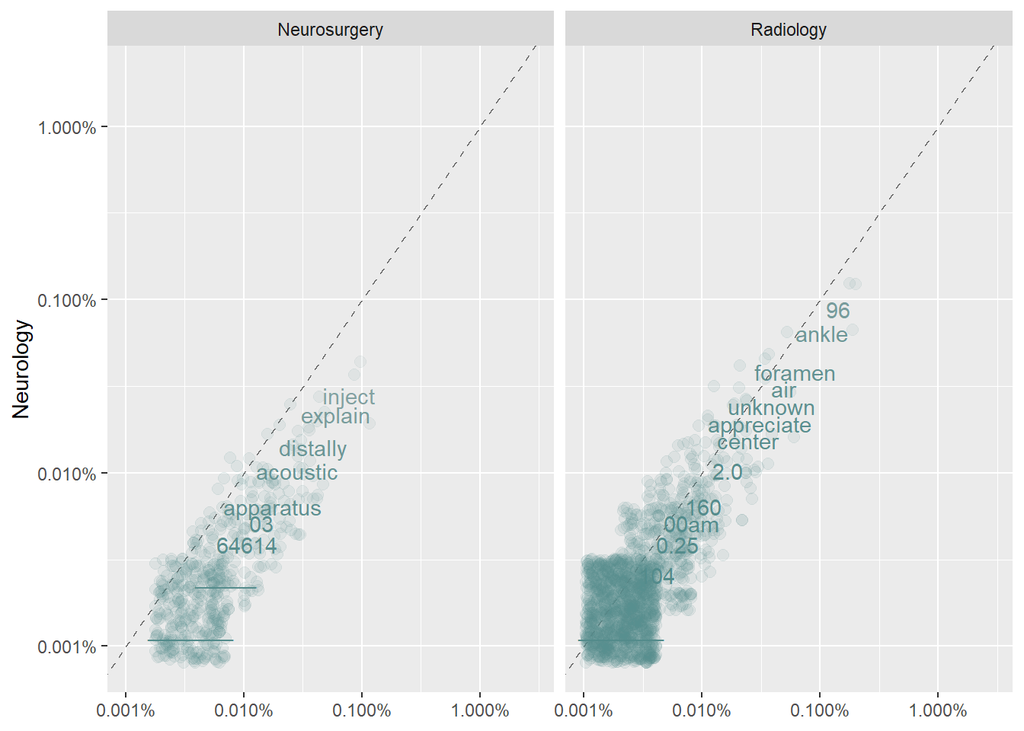

```r
ggplot2::ggplot(lemma.freq, ggplot2::aes(x=proportion,
                                         y=`Neurology`,
                                         color=abs(`Neurology` - proportion))) +
  ggplot2::geom_abline(color="gray40", lty=2) +
  ggplot2::geom_jitter(alpha=0.1, size=2.5, width=0.3, height=0.3) +
  ggplot2::geom_text(ggplot2::aes(label=lemma), check_overlap=TRUE, vjust=1.5) +
  ggplot2::scale_x_log10(labels=scales::percent_format()) +
  ggplot2::scale_y_log10(labels=scales::percent_format()) +
  ggplot2::scale_color_gradient(limits=c(0, 0.001), low="darkslategray4", high="gray75") +
  ggplot2::facet_wrap(~medical_specialty, ncol = 2) +
  ggplot2::theme(legend.position="none") +
  ggplot2:: labs(y="Neurology", x = NULL)
```

**6** What does this plot tell you about the relative similarity of lemma frequencies between neurosurgery and neurology and between radiology and neurosurgery? Based on what these specialties involve, is this what you would expect?

**Q6 Answer: It looks like a greater density of overlapping terms in neurology and radiology, compared to neurology and neurosurgery. At face value this is surprising to me- I would have expected a greater overlap between neurology and neurosurgery, but perhaps this just reflects my lack of familiarity with these specialties?** **Though the lower end of the distribution (bottom left square clusters) is shifted to the right on the neurosurgery/neurology graph, which suggests these overlapping terms are used a bit more in neurosurgery compared to the lower end of the overlapping terms in radiology.**

**7** Modify the above plotting code to do a direct comparison of Neurosurgery and Radiology (i.e., have Neurosurgery or Radiology on the Y-axis and the other 2 specialties as the X facets)

**Q7 Answer:**

**Calculate lemma frequencies:**

```r
lemma.freq <- lemmatized.data %>%
  dplyr::count(medical_specialty, lemma) %>%
  dplyr::group_by(medical_specialty) %>%
  dplyr::mutate(proportion = n / sum(n)) %>%
  tidyr::pivot_wider(names_from = medical_specialty, values_from = proportion) %>%
  tidyr::pivot_longer(`Neurosurgery`:`Neurology`,
               names_to = "medical_specialty", values_to = "proportion")
```

**Plot the relative proportions:**

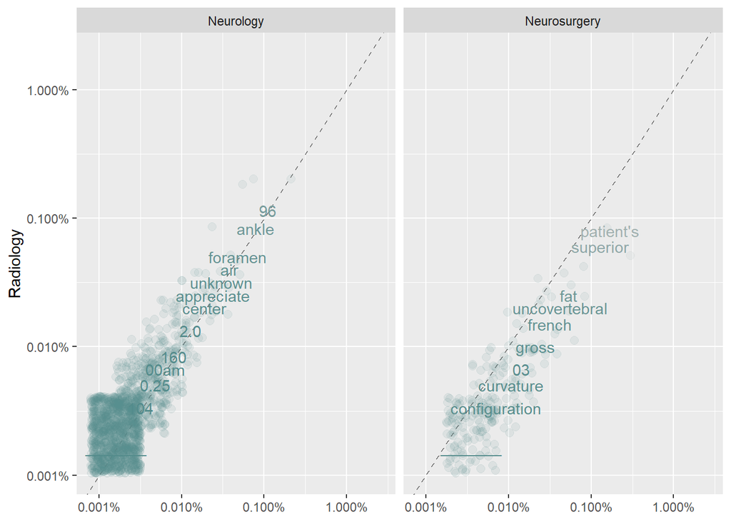

```r
ggplot2::ggplot(lemma.freq, ggplot2::aes(x=proportion,
                                         y=`Radiology`,
                                         color=abs(`Radiology` - proportion))) +
  ggplot2::geom_abline(color="gray40", lty=2) +
  ggplot2::geom_jitter(alpha=0.1, size=2.5, width=0.3, height=0.3) +
  ggplot2::geom_text(ggplot2::aes(label=lemma), check_overlap=TRUE, vjust=1.5) +
  ggplot2::scale_x_log10(labels=scales::percent_format()) +
  ggplot2::scale_y_log10(labels=scales::percent_format()) +
  ggplot2::scale_color_gradient(limits=c(0, 0.001), low="darkslategray4", high="gray75") +
  ggplot2::facet_wrap(~medical_specialty, ncol = 2) +
  ggplot2::theme(legend.position="none") +
  ggplot2:: labs(y="Radiology", x = NULL)
```

**Here we see something similar: much greater density of overlap between radiology and neurology, with a right-shift of the lower end of the distribution between radiology and neurosurgery.**

### TF-IDF Normalisation

Maybe looking at lemmas across all notes in a specialty is misleading, what if we look at lemma frequencies across a specialty.

```r
lemma.counts <- lemmatized.data %>% dplyr::count(medical_specialty, lemma)
total.counts <- lemma.counts %>%
                      dplyr::group_by(medical_specialty) %>%
                      dplyr::summarise(total=sum(n))

all.counts <- dplyr::left_join(lemma.counts, total.counts)
```

Now we can calculate the term frequency / invariant document frequency (tf-idf):

```r
all.counts.tfidf <- tidytext::bind_tf_idf(all.counts, lemma, medical_specialty, n)
```

We can then look at the top 10 lemma by tf-idf within each specialty:

```r
all.counts.tfidf %>% dplyr::group_by(medical_specialty) %>% dplyr::slice_max(order_by=tf_idf, n=10)
```

```
## # A tibble: 31 x 7
## # Groups:   medical_specialty [3]
##    medical_specialty lemma          n total       tf   idf   tf_idf
##    <chr>             <chr>      <int> <int>    <dbl> <dbl>    <dbl>
##  1 Neurology         speech        89 62573 0.00142  0.405 0.000577
##  2 Neurology         93            87 62573 0.00139  0.405 0.000564
##  3 Neurology         impression    86 62573 0.00137  0.405 0.000557
##  4 Neurology         sleep         82 62573 0.00131  0.405 0.000531
##  5 Neurology         b.i.d         30 62573 0.000479 1.10  0.000527
##  6 Neurology         cn            78 62573 0.00125  0.405 0.000505
##  7 Neurology         drug          77 62573 0.00123  0.405 0.000499
##  8 Neurology         hx            70 62573 0.00112  0.405 0.000454
##  9 Neurology         96            69 62573 0.00110  0.405 0.000447
## 10 Neurology         fhx           63 62573 0.00101  0.405 0.000408
## # ... with 21 more rows
```

**8** Are there any lemmas that stand out in these lists? Why?

**Q8 Answer: I’m not very familiar with neurology, but “impression” is an interesting one. Is this because doctors are writing their subjective impressions of the patient? Perhaps standard terminology for a conservative assessment in the field? Also some frequently used numbers that I’m unsure of why they would be here. The abbreviations (b.i.d., cn, hx, fhx) and other lemmas seem routine.**

We can look at transcriptions using these unusual lemmas to check how they are used with `stringr::str_detect`

```r
analysis.data %>% dplyr::select(medical_specialty, transcription) %>% dplyr::filter(stringr::str_detect(transcription, 'b.i.d')) %>% dplyr::slice(1)
```

```
##   medical_specialty
## 1         Radiology
##                                                                                                                                                                                                                                                                                                          …
## 1 CC:, Episodic monocular blindness, OS.,HX:, This 29 y/o RHF was in her usual healthy state until 2 months prior to her 3/11/96 presentation when she developed episodic arthralgias of her knees and ankles, bilaterally. On 3/3/96, she experienced sudden onset monocular blindness, OS, lasting 5-10…
```

**9** Extract an example of one of the other unusual “top lemmas” by modifying the above code

**Q9 Answer: I’m familiar with the abbreviations so those didn’t seem unusual to me (except cn but a quick Google search clarified that). And from the last code I now see that we likely have a lot of notes from 1993 and 1996, which explains the numbers. So let’s see how impression is being used:**

```r
analysis.data %>% dplyr::select(medical_specialty, transcription) %>% dplyr::filter(stringr::str_detect(transcription, 'impression')) %>% dplyr::slice(1)
```

```
##   medical_specialty
## 1         Radiology
##                                                                                                                                                                                                                                                                                                          …
## 1 INTERPRETATION: , MRI of the cervical spine without contrast showed normal vertebral body height and alignment with normal cervical cord signal.  At C4-C5, there were minimal uncovertebral osteophytes with mild associated right foraminal compromise.  At C5-C6, there were minimal diffuse disc bu…
```

**Impression seems to be used as indicating the clinician’s overall assessment.**

## Topic Modelling

In NLP, we often have collections of documents (in our case EMR transcriptions) that we’d like to divide into groups so that we can understand them separately. Topic modeling is a method for unsupervised classification of such documents, similar to clustering on numeric data.

Latent Dirichlet allocation (LDA) is a particularly popular method for fitting a topic model. It treats each document as a mixture of topics, and each topic as a mixture of words. This allows documents to “overlap” each other in terms of content, rather than being separated into discrete groups, in a way that mirrors typical use of natural language.

- Every document is a mixture of topics. We imagine that each document may contain words from several topics in particular proportions. For example, in a two-topic model we could say “Document 1 is 90% topic A and 10% topic B, while Document 2 is 30% topic A and 70% topic B.”
- Every topic is a mixture of words. For example, we could imagine a two-topic model of American news, with one topic for “politics” and one for “entertainment.” The most common words in the politics topic might be “President”, “Congress”, and “government”, while the entertainment topic may be made up of words such as “movies”, “television”, and “actor”. Importantly, words can be shared between topics; a word like “budget” might appear in both equally.

LDA is a mathematical method for estimating both of these at the same time: finding the mixture of words that is associated with each topic, while also determining the mixture of topics that describes each document. There are a number of existing implementations of this algorithm, and we’ll explore one of them in depth.

First lets calculate a term frequency matrix for each transcription:

```r
lemma.counts <- lemmatized.data %>% dplyr::count(note_id, lemma)
total.counts <- lemma.counts %>%
                      dplyr::group_by(note_id) %>%
                      dplyr::summarise(total=sum(n))

all.counts <- dplyr::left_join(lemma.counts, total.counts)
emr.dcm <- all.counts %>% tidytext::cast_dtm(note_id, lemma, n)
```

Then we can use LDA function to fit a 3 topic (`k=3`) LDA-model

```r
emr.lda <- topicmodels::LDA(emr.dcm, k=3, control=list(seed=42))
emr.topics <- tidytext::tidy(emr.lda, matrix='beta')
```

Then we can extract the top terms per assigned topic:

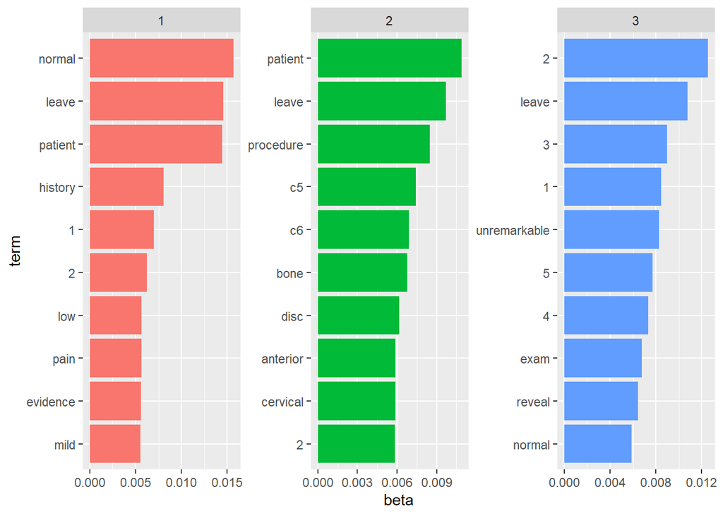

```r
top.terms <- emr.topics %>% dplyr::group_by(topic) %>%
  dplyr::slice_max(beta, n=10) %>%
  dplyr::ungroup() %>%
  dplyr::arrange(topic, -beta)


top.terms %>%
  dplyr::mutate(term=tidytext::reorder_within(term, beta, topic)) %>%
  ggplot2::ggplot(ggplot2::aes(beta, term, fill=factor(topic))) +
    ggplot2::geom_col(show.legend=FALSE) +
    ggplot2::facet_wrap(~ topic, scales='free')  +
    tidytext::scale_y_reordered()
```

Now we can ask how well do these assigned topics match up to the medical specialties from which each of these transcripts was derived.

```r
specialty_gamma <- tidytext::tidy(emr.lda, matrix='gamma')

# we need to join in the specialty from the note_id
note_id_specialty_mapping <- lemmatized.data %>%
  dplyr::mutate(document=as.character(note_id)) %>%
  dplyr::select(document, medical_specialty) %>%
  dplyr::distinct()

specialty_gamma <- dplyr::left_join(specialty_gamma, note_id_specialty_mapping)
```

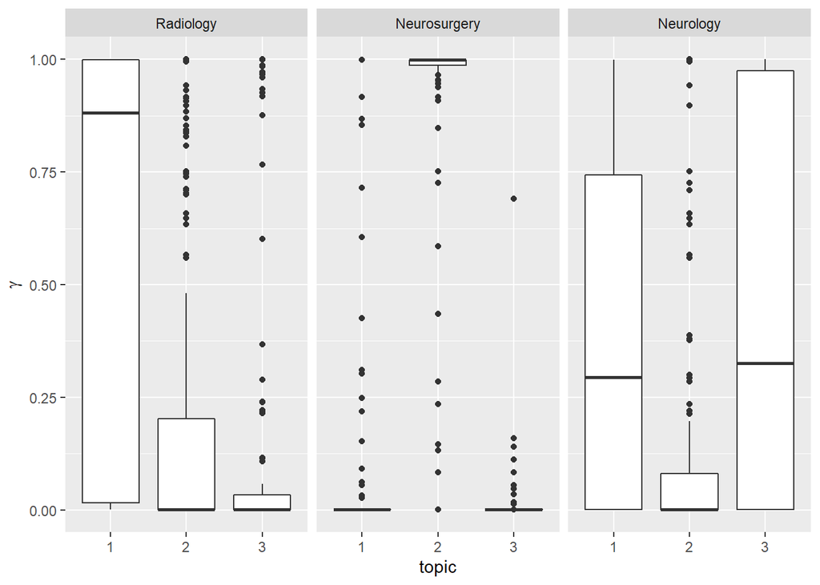

```r
specialty_gamma %>%
  dplyr::mutate(medical_specialty = reorder(medical_specialty, gamma * topic)) %>%
  ggplot2::ggplot(ggplot2::aes(factor(topic), gamma)) +
  ggplot2::geom_boxplot() +
  ggplot2::facet_wrap(~ medical_specialty) +
  ggplot2::labs(x = "topic", y = expression(gamma))
```

Interestingly, neurosurgery assigns mostly to a single topic but radiology and neurology are both more diverse in transcriptions. We’d possibly expect this from radiology due to referring to imaging for many different diagnoses/reasons. However, this may all just reflect we are using too few topics in our LDA to capture the range of possible assignments.

**10** Repeat this with a 6 topic LDA, do the top terms from the 3 topic LDA still turn up? How do the specialties get split into sub-topics?

**Q10 Answer:**

**LDA function to fit a 6 topic (`k=6`) LDA-model**

```r
emr.lda <- topicmodels::LDA(emr.dcm, k=6, control=list(seed=42))
emr.topics <- tidytext::tidy(emr.lda, matrix='beta')
```

**Extract the top terms per assigned topic:**

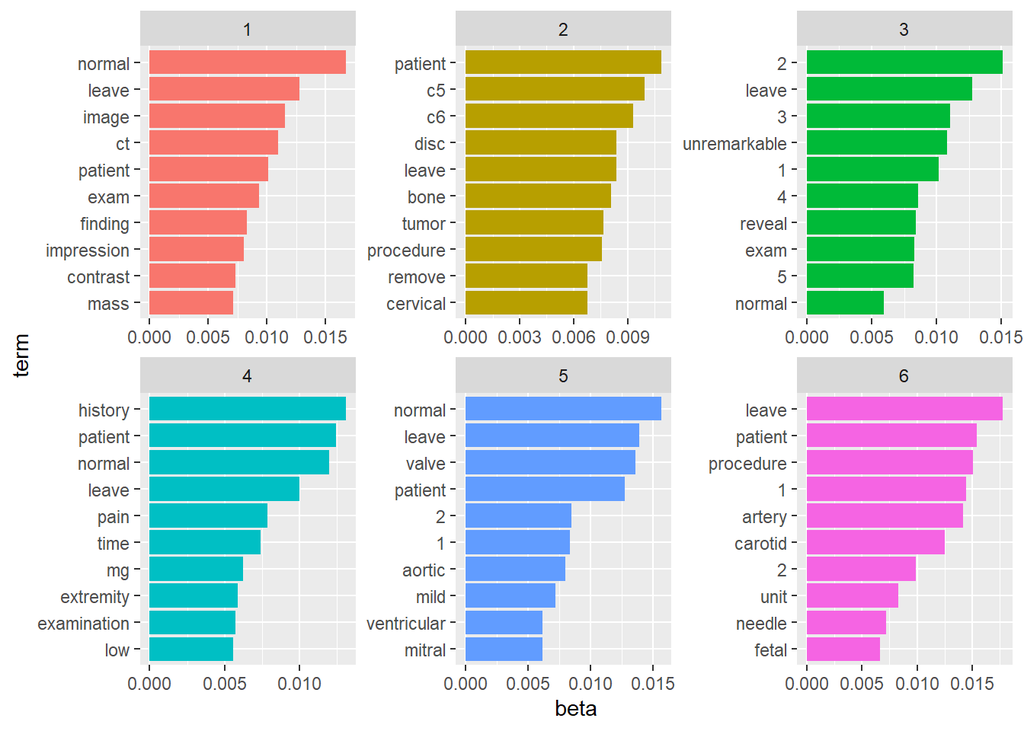

```r
top.terms <- emr.topics %>% dplyr::group_by(topic) %>%
  dplyr::slice_max(beta, n=10) %>%
  dplyr::ungroup() %>%
  dplyr::arrange(topic, -beta)


top.terms %>%
  dplyr::mutate(term=tidytext::reorder_within(term, beta, topic)) %>%
  ggplot2::ggplot(ggplot2::aes(beta, term, fill=factor(topic))) +
    ggplot2::geom_col(show.legend=FALSE) +
    ggplot2::facet_wrap(~ topic, scales='free')  +
    tidytext::scale_y_reordered()
```

**The 3-topic LDA gave normal, patient, leave, and procedure as the top terms. These still appear to be the top terms with 6 topics. Now let’s see how the specialties get split:**

```r
specialty_gamma <- tidytext::tidy(emr.lda, matrix='gamma')

# we need to join in the specialty from the note_id
note_id_specialty_mapping <- lemmatized.data %>%
  dplyr::mutate(document=as.character(note_id)) %>%
  dplyr::select(document, medical_specialty) %>%
  dplyr::distinct()

specialty_gamma <- dplyr::left_join(specialty_gamma, note_id_specialty_mapping)
```

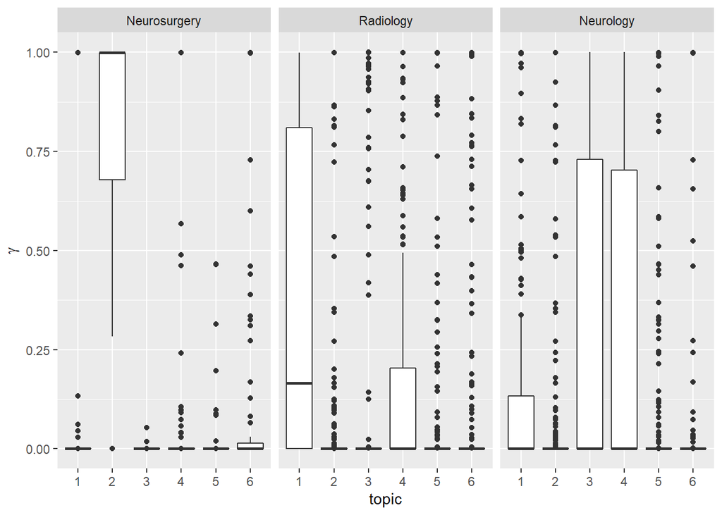

```r
specialty_gamma %>%
  dplyr::mutate(medical_specialty = reorder(medical_specialty, gamma * topic)) %>%
  ggplot2::ggplot(ggplot2::aes(factor(topic), gamma)) +
  ggplot2::geom_boxplot() +
  ggplot2::facet_wrap(~ medical_specialty) +
  ggplot2::labs(x = "topic", y = expression(gamma))
```

## Credits

Examples draw heavily on material (and directly quotes/copies text) from Julia Slige’s `tidytext` textbook.